# STA257

Last edited: 2016-11-16 19:26

## conditional distributions and independence

Suppose \(X\) and \(Y\) are independent so that \(f(x,y) = {f_{\tiny{X}}}(x)\,{f_{\tiny{Y}}}(y)\).

Then: \[\begin{align*} {f_{\tiny{X|Y}}}(x|y) &= \frac{f(x,y)}{{f_{\tiny{Y}}}(y)}\\ &=\frac{{f_{\tiny{X}}}(x)\,{f_{\tiny{Y}}}(y)}{{f_{\tiny{Y}}}(y)}\\ &= {f_{\tiny{X}}}(x) \end{align*}\] I would argue: *as expected*.

## the bivariate normal distributions - a very fast introduction to an important class of joint distributions

## bivariate normal - independent \(N(0,1)\) case

Start with \(X \sim N(0,1)\) and \(Y \sim N(0,1)\) with \(X \perp Y\). The joint density will be: \[f(x,y) = \frac{1}{2\pi}\exp{\left(-\frac{1}{2}\left(x^2 + y^2\right)\right)}\]

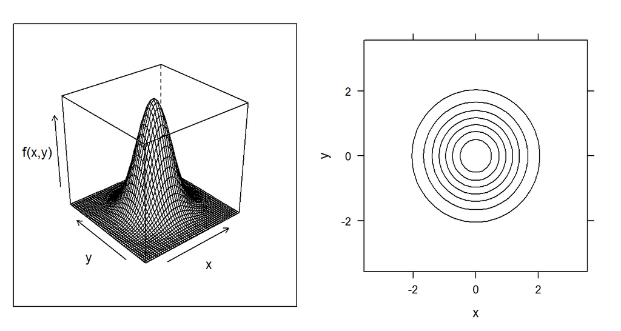

## bivariate normal - independent general case

If we let \(X \sim N(\mu_x, \sigma^2_x)\) and \(Y \sim N(\mu_y, \sigma^2_y)\) with \(X \perp Y\) the joint density is: \[\begin{align*} f(x,y) &= \frac{1}{\sigma_x\sigma_y2\pi}\exp{\left(-\frac{1}{2}\left[\left(\frac{x-\mu_x}{\sigma_x}\right)^2 + \left(\frac{y-\mu_y}{\sigma_y}\right)^2\right]\right)}\\ &= \frac{1}{\sigma_x\sigma_y2\pi}\exp{\left(-\frac{1}{2}\left[a^2 + b^2\right]\right)} \end{align*}\]

With:

\[a = \frac{x-\mu_x}{\sigma_x} \hspace{2cm} b = \frac{y-\mu_y}{\sigma_y}\]

## free pictures of some joint independent normals

\[\mu_x = 10\qquad\sigma^2_x=1\hspace{4cm}\mu_x=3\qquad \sigma^2_x=4\\ \mu_y = -1\qquad\sigma^2_y=9\hspace{4cm}\mu_y=2\qquad \sigma^2_y=\frac{1}{4}\]

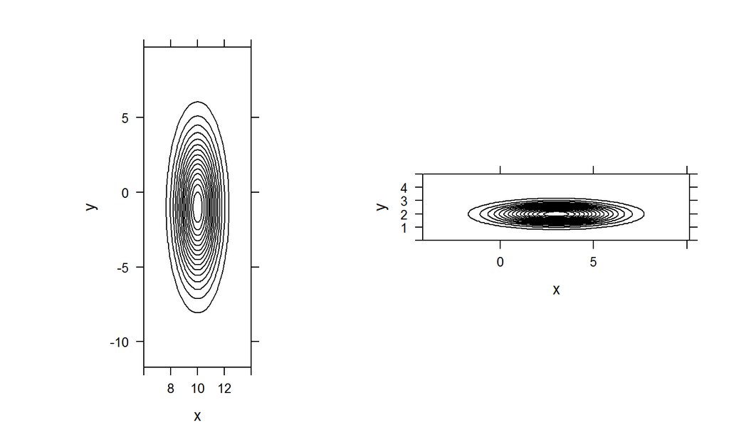

## bivariate normals - general case

This is not obvious. Start with the bivariate independent case, re-jigged: \[\begin{align*}f(x,y)&=\frac{1}{\sigma_x\sigma_y2\pi}\exp{\left(-\frac{1}{2}\left[a^2 + b^2\right]\right)}\\ &=\frac{1}{\sqrt{1-0^2}\sigma_x\sigma_y2\pi}\exp{\left(-\frac{1}{2}\left[a^2 -2\cdot0\cdot ab+ b^2\right]\right)} \end{align*}\] Why? Because I said so.

Now let plug in a new constant \(\rho\) with \(-1 < \rho < 1\) (Why? Because.) where the 0 lives to get the general case:

\[\frac{1}{\sqrt{1-\rho^2}\sigma_x\sigma_y2\pi}\exp{\left(-\frac{1}{2}\left[a^2 -2\rho ab+ b^2\right]\right)}\]

## free pictures

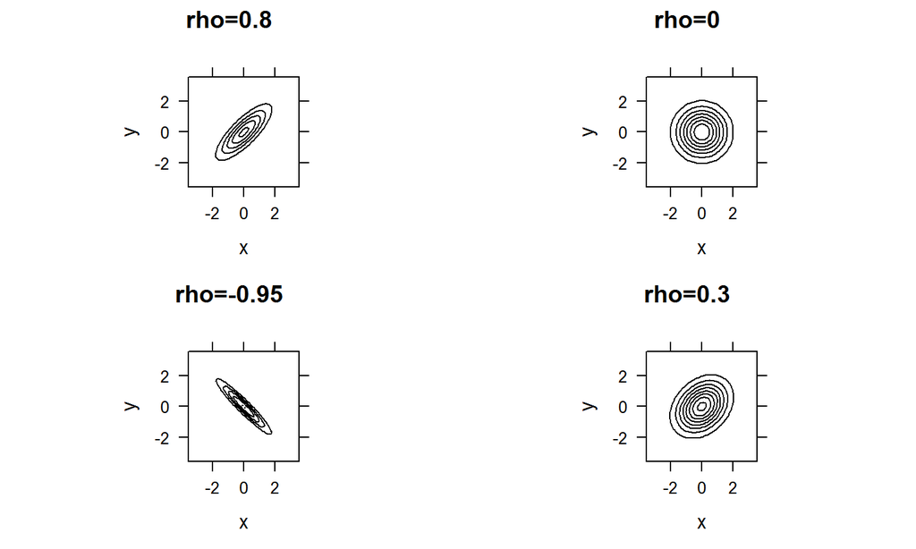

## facts (some as exercises)

Fact: Marginals of bivariate normals have normal distribution. (Exercise: very carefully follow technique demonstrated on pp. 82-83 of the textbook.)

Fact: Conditional distributions \(X|Y=y\) and \(Y|X=x\) also have normal distributions. (Exercise: the book gives the "answer" but seems to think it's too hard. It isn't. Use the identity \(a^2-2\rho ab + b^2 = (1-\rho^2)b^2 + (a-\rho b)^2\))

Fact: Any "slice" along any line \(z = \alpha x + \beta y\) will also have a normal distribution (to be shown later).

Fact: These facts *characterize* bivariate normal distrbutions (advanced)

Opinion: Bi- and multi-variate normals are best worked with using vector and matrix notation…but that is for a different course.

## distributions of functions of multiple random variables with focus on the continuous case

## stay woke

Probably way more important than the DOFORV situation, but we'll focus on the "classics" and leave the fully general case to other courses.

Here are the classics. Suppose \(X\) and \(Y\) have joint density \(f(x,y)\). Consider:

\[g_1(x,y) = x + y \qquad g_2(x,y) = y\,/\,x\] These are smooth functions \(\mathbb{R}^2 \to \mathbb{R}\).

What are the distributions of:

\[W_1=g_1(X,Y) = X + Y \qquad W_2=g_2(X,Y) = Y\,/\,X \] Technique: the cdf of the \(W_i\) is an integral of \(f(x,y)\) over a certain region.

## the classic density formulae: \(W_1 = X + Y\)

\[\begin{align*} {f_{\tiny{W_1}}}(w) &= \int\limits_{-\infty}^\infty f(x, w-x)\,dx\\ &= \int\limits_{-\infty}^\infty {f_{\tiny{X}}}(x){f_{\tiny{Y}}}(w-x)\,dx \quad \left(\text{when } X\perp Y\right) \end{align*}\] Proof:…

Example: \(X \sim N(0,1)\) and \(Y \sim N(0,1)\) with \(X \perp Y\).

Example: \(X \sim\text{Unif}[0,1]\) and \(Y \sim\text{Unif}[0,1]\) with \(X\perp Y\).

Exercise (textbook example): \(X \sim \text{Exp}(\lambda)\) and \(Y \sim \text{Exp}(\lambda)\) with \(X \perp Y\)